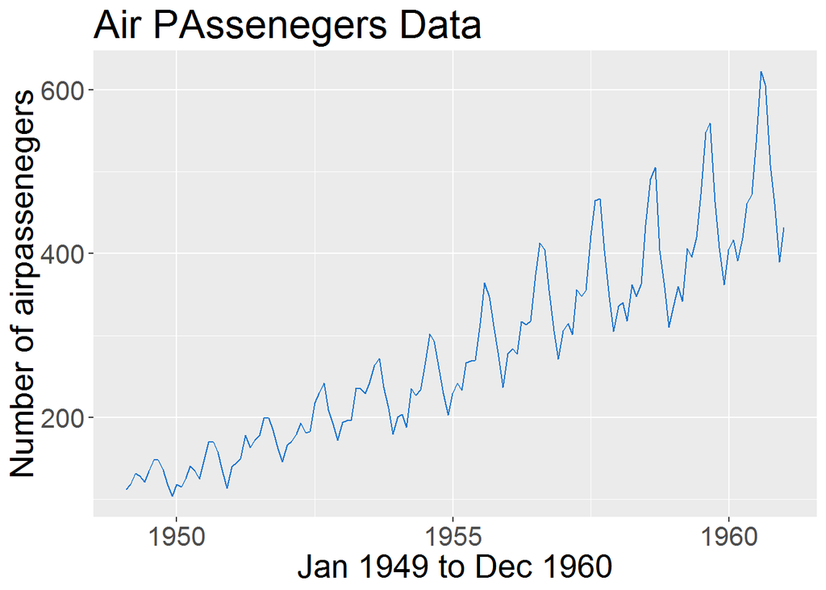

```r
library(ggplot2)
library(ggfortify)
library(timeSeries)
library("datasets")
autoplot(
  as.timeSeries(AirPassengers),
  ts.colour = "dodgerblue3",
  main = "Air PAssenegers Data",
  xlab = "Jan 1949 to Dec 1960",
  ylab = "Number of airpassenegers") +
  theme(text = element_text(size = 20))
```

## Converting sorted data into TS data

```r
library(zoo)
rm(list = ls())
dates <- seq(as.Date("2018/1/1"), as.Date("2018/1/10"), "day")
values <- as.vector(floor(runif(10, 1, 500)))
```

Forming a zoo object

```r
zoo_object <- zoo(values, order.by = as.Date(dates))
class(zoo_object)
```

```
## [1] "zoo"
```

Converting zoo object into TS

```r
ts_data <- ts(zoo_object)
class(ts_data)
```

```
## [1] "ts"
```

## COnverting unsorted data into timeseries data

```r
reshuffled_date <- as.data.frame(sample(dates))
class(reshuffled_date)
```

```
## [1] "data.frame"
```

```r
undf <- cbind(reshuffled_date, values)
class(undf)
```

```
## [1] "data.frame"
```

```r
head(undf)
```

```
##   sample(dates) values
## 1    2018-01-09    342
## 2    2018-01-04    401
## 3    2018-01-06    132
## 4    2018-01-08    351
## 5    2018-01-01    233
## 6    2018-01-10    392
```

```r
zoo_object <- zoo(undf[,2], order.by = as.Date(undf[,1]),
                  unique(T))
class(zoo_object)
```

```
## [1] "zooreg" "zoo"
```

```r
zoo_object
```

```
## 2018-01-01 2018-01-02 2018-01-03 2018-01-04 2018-01-05 2018-01-06
##        233        235          3        401        113        132
## 2018-01-07 2018-01-08 2018-01-09 2018-01-10
##        499        351        342        392
```

We then use the ts() function to create a time series data using zoo object

```r
timeseries_data <- ts(zoo_object)
timeseries_data
```

```
## Time Series:
## Start = 1
## End = 10
## Frequency = 1
##  [1] 233 235   3 401 113 132 499 351 342 392
## attr(,"index")
##  [1] "2018-01-01" "2018-01-02" "2018-01-03" "2018-01-04" "2018-01-05"
##  [6] "2018-01-06" "2018-01-07" "2018-01-08" "2018-01-09" "2018-01-10"
## attr(,"frequency")
## [1] TRUE
```

## Components of TS data

### Trend

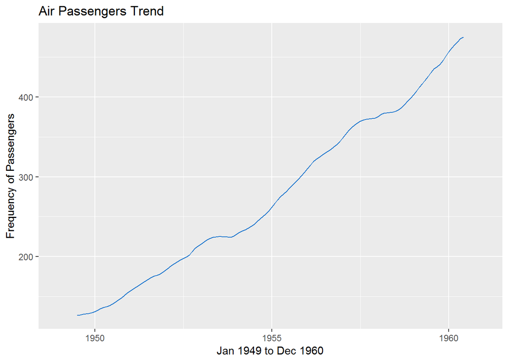

```r
autoplot(decompose(AirPassengers)$trend,
         ts.colour = "dodgerblue3",
         main = "Air Passengers Trend",
         xlab = "Jan 1949 to Dec 1960",
         ylab = "Frequency of Passengers")
```

```r
library(fma)
```

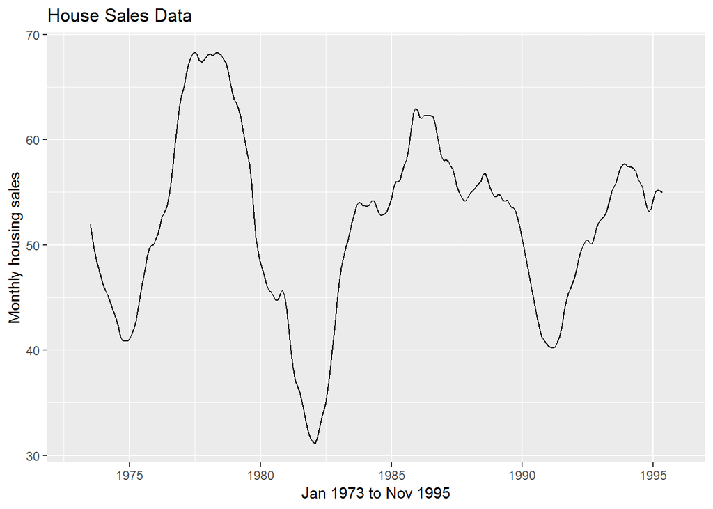

```r
autoplot(decompose(hsales)$trend,
         ts.colour = "dodgerblue3",
         main = "House Sales Data",
         xlab = "Jan 1973 to Nov 1995",
         ylab = "Monthly housing sales")
```

### Seasonal

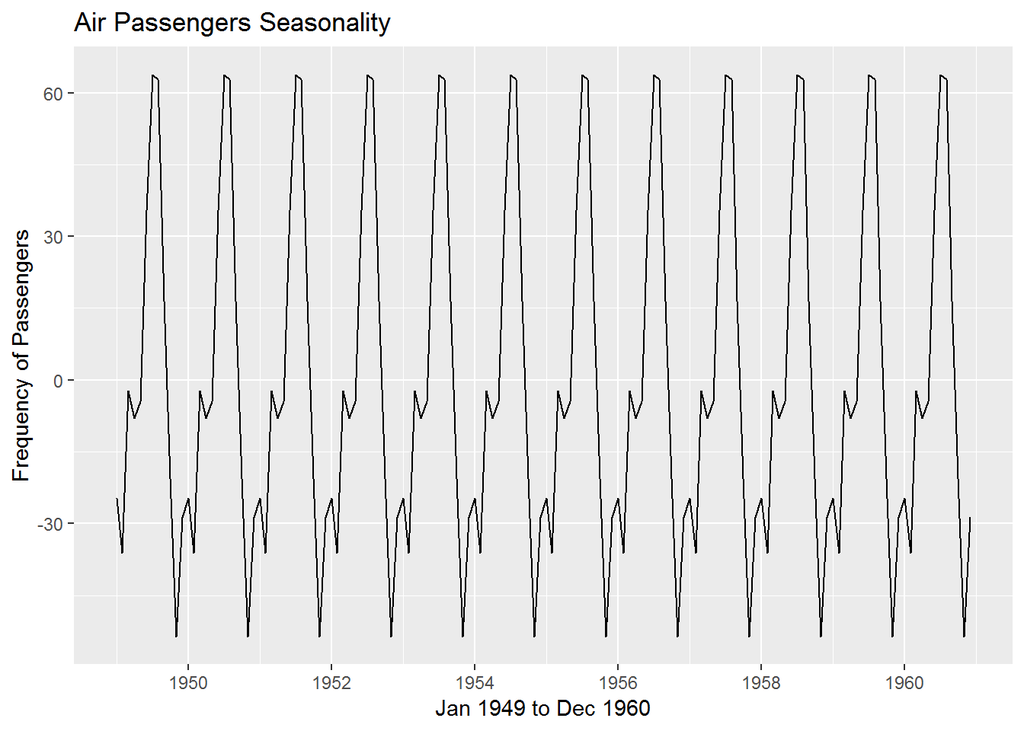

```r
autoplot(decompose(AirPassengers)$seasonal,
         ts.colour = "dodgerblue3",
         main = "Air Passengers Seasonality",
         xlab = "Jan 1949 to Dec 1960",
         ylab = "Frequency of Passengers")
```

To get seasonal data for 1 year

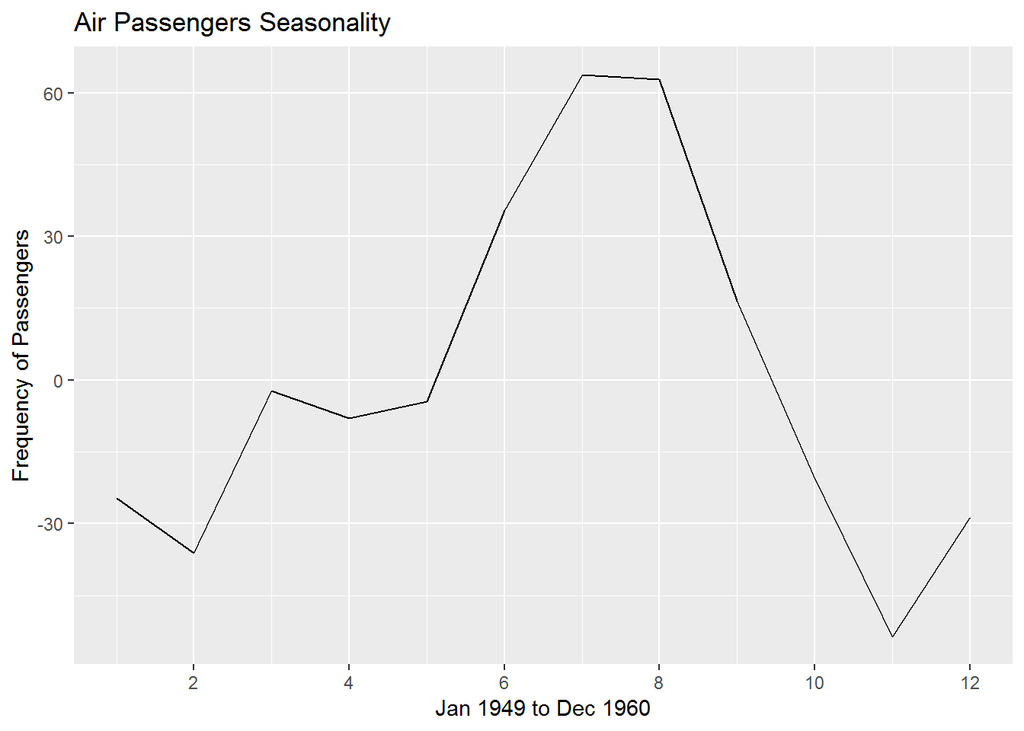

```r
passenegrs <- decompose(AirPassengers)
autoplot(ts(passenegrs$seasonal[1:12]),
         ts.colour = "dodgerblue3",
         main = "Air Passengers Seasonality",
         xlab = "Jan 1949 to Dec 1960",
         ylab = "Frequency of Passengers")
```

As AirPassengers does not exhibit cyclic variations, let’s analyze the hsales dataset

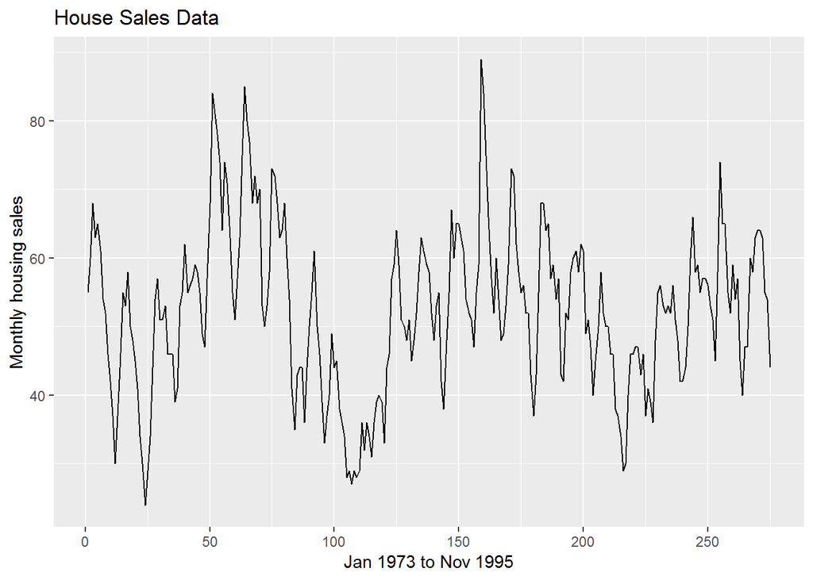

```r
autoplot(ts(hsales),
         ts.colour = "dodgerblue3",
         main = "House Sales Data",
         xlab = "Jan 1973 to Nov 1995",
         ylab = "Monthly housing sales")
```

When irregular fluctuations occur in the time series data, they can be categorized under Random factors.

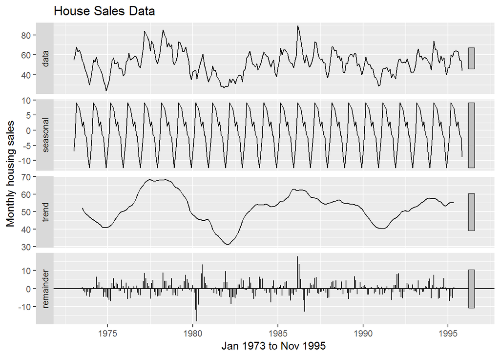

```r
autoplot(decompose(hsales),
         ts.colour = "dodgerblue3",
         main = "House Sales Data",
         xlab = "Jan 1973 to Nov 1995",
         ylab = "Monthly housing sales")
```

If the three components of a time series graph are missing i.e. trends, seasonality or cyclic then the time series data is termed as random. Time series data does not need to have all the components.

## Additive Model and deseasonalized data

Converting AirPassengers Data into yearly format

```r
rm(list = ls())
AP <- ts(AirPassengers[1:132],       # not considering values for year 1960
         frequency = 12)             # Yearly format
```

Decomposing the TS data

```r
decomposedAP <- decompose(AP,
                          type = "additive")
summary(decomposedAP)
```

```
##          Length Class  Mode
## x        132    ts     numeric
## seasonal 132    ts     numeric
## trend    132    ts     numeric
## random   132    ts     numeric
## figure    12    -none- numeric
## type       1    -none- character
```

```r
# decomposedAP$trend                  # Gives trend values
# decomposedAP$seasonal               # Gives seasonal values per value
# decomposedAP$figure                 # Gives overall seasonal value
```

Deseasonalized data

```r
deseasonalized_data <- AirPassengers - decomposedAP$figure
```

If it was for quarter we will consider freq as 4 while decomposing and use AP variable instead of Airpassengers.

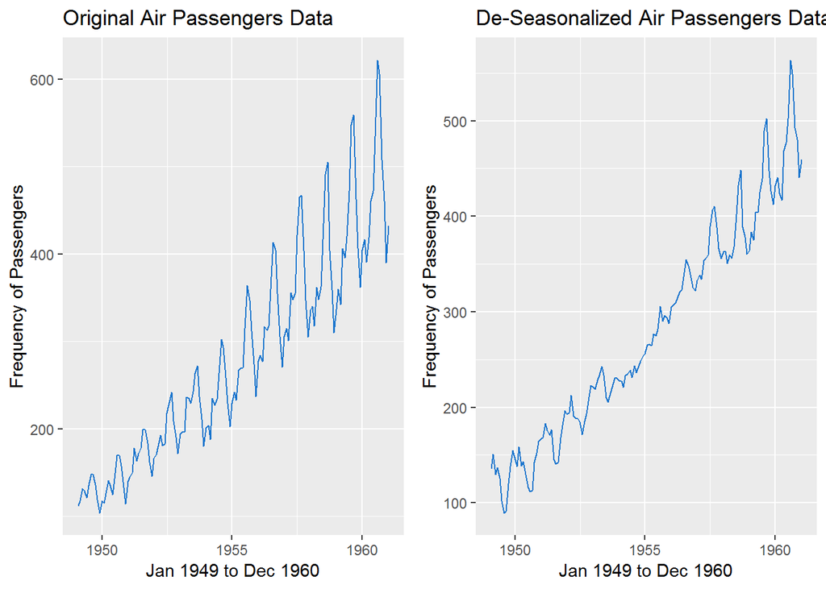

```r
library(gridExtra)
library(grid)
p1 <- autoplot(as.timeSeries(AirPassengers),
         ts.colour = "dodgerblue3",
         main = "Original Air Passengers Data",
         xlab = "Jan 1949 to Dec 1960",
         ylab = "Frequency of Passengers")

p2 <- autoplot(as.timeSeries(deseasonalized_data),
         ts.colour = "dodgerblue3",
         main = "De-Seasonalized Air Passengers Data",
         xlab = "Jan 1949 to Dec 1960",
         ylab = "Frequency of Passengers")

grid.arrange(p1, p2, ncol = 2)
```

Decomposition using Addition

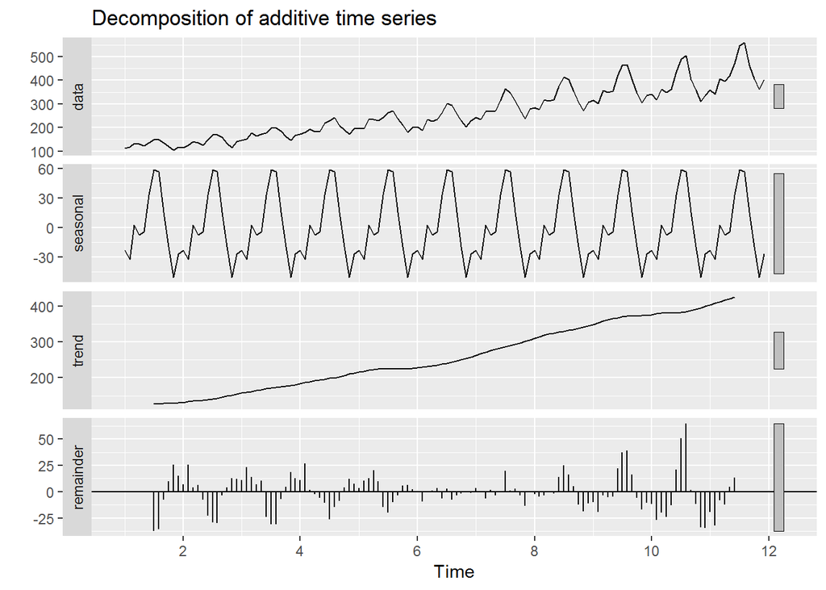

```r
autoplot(decompose(AP,
                   type = "additive"))
```

## Multiplicative Model and deseasonalized data

Decomposing the TS data

```r
decomposedAP <- decompose(AP, type = "multiplicative")
summary(decomposedAP)
```

```
##          Length Class  Mode
## x        132    ts     numeric
## seasonal 132    ts     numeric
## trend    132    ts     numeric
## random   132    ts     numeric
## figure    12    -none- numeric
## type       1    -none- character
```

```r
#decomposedAP$trend                  # Gives trend values
#decomposedAP$seasonal               # Gives seasonal values per value
#decomposedAP$figure                 # Gives overall seasonal value
```

Deseasonalized data

```r
deseasonalized_data <- AirPassengers / decomposedAP$figure
```

Original TS Data

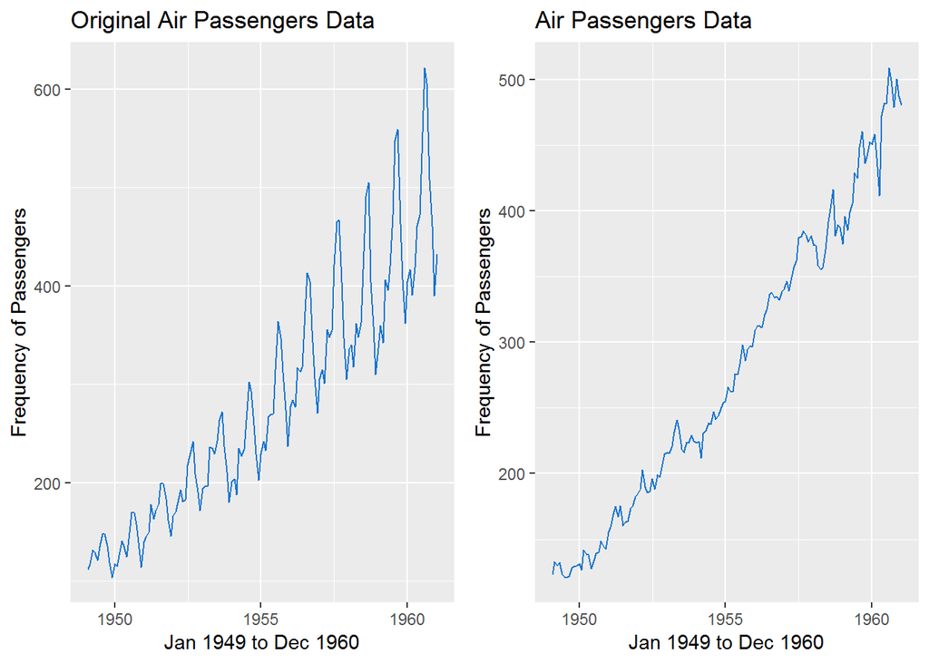

```r
p1 <- autoplot(as.timeSeries(AirPassengers),
         ts.colour = "dodgerblue3",
         main = "Original Air Passengers Data",
         xlab = "Jan 1949 to Dec 1960",
         ylab = "Frequency of Passengers")

p2 <- autoplot(as.timeSeries(deseasonalized_data),
         ts.colour = "dodgerblue3",
         main = "Air Passengers Data",
         xlab = "Jan 1949 to Dec 1960",
         ylab = "Frequency of Passengers")

grid.arrange(p1,p2,ncol=2)
```

From Fig of (Additive model) we may observe that there are more variations in the trend as compared to Fig of (Multiplicative model). By looking at these observations we may conclude that deseasonalized AirPassengers data might give us a clearer trend using multiplicative model.

## Smoothing TS data

### 1. Simple Moving Averages

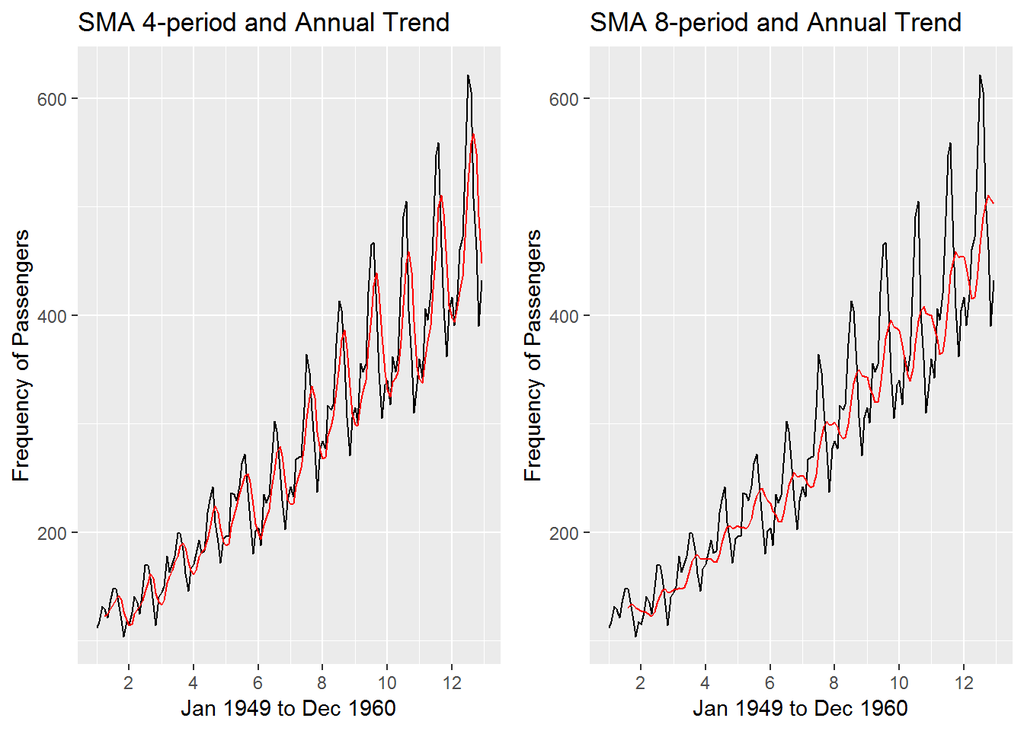

```r
library(TTR)
library(ggplot2)
library(gridExtra)
library(grid)

AP <- ts(AirPassengers, frequency = 12)
TrendPattern4 <- SMA(AP, n = 4)                # try for n = 8
TrendPattern8 <- SMA(AP, n = 8)

p1 <- autoplot(AP,
         main = "SMA 4-period and Annual Trend",
         xlab = "Jan 1949 to Dec 1960",
         ylab = "Frequency of Passengers") +
  geom_line(aes(y = TrendPattern4), colour = "red")

p2 <- autoplot(AP,
         main = "SMA 8-period and Annual Trend",
         xlab = "Jan 1949 to Dec 1960",
         ylab = "Frequency of Passengers") +
  geom_line(aes(y = TrendPattern8), colour = "red")

grid.arrange(p1,p2,ncol=2)
```

We can observe 4 period moving average of the AirPassengers has lots off variations as compared to 8 period moving average.

Under-smoothning <- with lower values of n Over-smoothning <- with higher values of n

The value of ‘n’ should be set in a manner where both under smoothing and over smoothing can be avoided.

The trend line is asymmetric in simple moving average.

### 2.Centered Moving Averages

We can make the trend line symmetric by placing the average in the middle of the time series, this is known as centered moving average. This works well for odd period moving average than even period moving average.

```r
CMA <- function(TS_val, n){
  filter(TS_val, rep(1/n,n), sides = 2)
}

TrendPattern_2 <- CMA(AirPassengers[1:12], 2)        # try with n = 3, 4, 5
TrendPattern_2
```

```
## Time Series:
## Start = 1
## End = 12
## Frequency = 1
##  [1] 115.0 125.0 130.5 125.0 128.0 141.5 148.0 142.0 127.5 111.5 111.0
## [12]    NA
```

```r
TrendPattern_3 <- CMA(AirPassengers[1:12], 3)
TrendPattern_4 <- CMA(AirPassengers[1:12], 4)
TrendPattern_5 <- CMA(AirPassengers[1:12], 5)
```

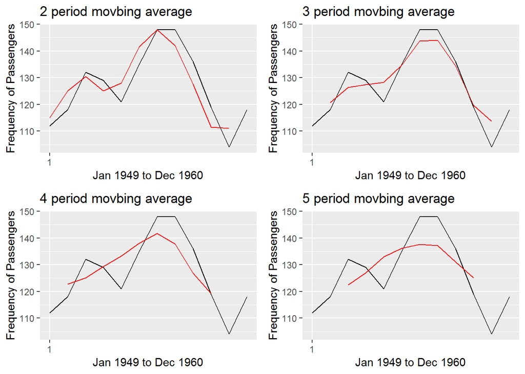

```r
AP <- ts(AirPassengers[1:12], frequency = 12)
p1 <- autoplot(AP,
         main = "2 period movbing average",
         xlab = "Jan 1949 to Dec 1960",
         ylab = "Frequency of Passengers") +
  geom_line(aes(y = TrendPattern_2), colour = "red")

p2 <- autoplot(AP,
         main = "3 period movbing average",
         xlab = "Jan 1949 to Dec 1960",
         ylab = "Frequency of Passengers") +
  geom_line(aes(y = TrendPattern_3), colour = "red")

p3 <- autoplot(AP,
         main = "4 period movbing average",
         xlab = "Jan 1949 to Dec 1960",
         ylab = "Frequency of Passengers") +
  geom_line(aes(y = TrendPattern_4), colour = "red")

p4 <- autoplot(AP,
         main = "5 period movbing average",
         xlab = "Jan 1949 to Dec 1960",
         ylab = "Frequency of Passengers") +
  geom_line(aes(y = TrendPattern_5), colour = "red")

grid.arrange(p1,p2,p3,p4, ncol=2)
```

Simple and centered moving average, however, treats the last n observations equally. All observations before that are ignored.

In some scenarios all of the past data must be given gradual weightage. Maximum weightage should be given to the most recent data while minimum weightage should be given to the least recent data or vice-versa. In between maximum and minimum there is a gradual change in the weightage which are assigned to the observations. This type of smoothing is called exponential smoothing.

## 3. Exponential Smoothing

If you are predicting for only 1 month then h=1.  
if you are predicting for all 12 months then h=12

```r
library(forecast)

for (temp in c(1:12)) {
  pred_val <- ses(AirPassengers[1:temp],
                  h = 1,                                   # Number of periods
                  initial = "simple",                      # Simple/Optimal
                  alpha = 0.2)                             # Alpha parameter
}
pred_val$fitted                                            # Smoothed TS
```

```
## Time Series:
## Start = 1
## End = 12
## Frequency = 1
##  [1] 112.0000 112.0000 113.2000 116.9600 119.3680 119.6944 122.7555
##  [8] 127.8044 131.8435 132.6748 129.9399 124.7519
```

##### Estimation of the Smoothing Constant - alpha

```r
library(Metrics)
print("To see mse values for different alpha")
```

```
## [1] "To see mse values for different alpha"
```

```r
for (temp in c(1:9)) {
  pred_val <- ses(AirPassengers[1:131],
                  h = 1,
                  initial = "simple",
                  alpha = temp/10)
  pred_val <- as.data.frame(pred_val)
  print(mse(AirPassengers[132], pred_val[,1]))
  mse_values <- mse(AirPassengers[132], pred_val[,1])
}
```

```
## [1] 134.881
## [1] 687.3971
## [1] 575.1071
## [1] 198.1702
## [1] 1.85554
## [1] 125.8294
## [1] 492.1954
## [1] 963.3302
## [1] 1432.313
```

### To get the optimal vaLUE OF ALPHA

```r
optimal_alpha <- function(x) {
  pred_val <- ses(AirPassengers[1:131],
                  h = 1,                                       # h=12 for whole month
                  initial = "simple",
                  alpha = x)
  pred_val <- as.data.frame(pred_val)
  return(mse(AirPassengers[132], pred_val[,1]))
}

library(pracma)
alpha_values <- fminbnd(optimal_alpha, 0, 1)
alpha_values$xmin
```

```
## [1] 0.5104932
```

#### Prediction for the next 12

Forecast value for the next 12 months along with the confidence interval

```r
prediction <- ses(AirPassengers[1:132], h = 12, initial = "simple", alpha = alpha_values$xmin)
prediction
```

```
##     Point Forecast    Lo 80    Hi 80    Lo 95    Hi 95
## 133            405 356.1695 453.8305 330.3202 479.6798
## 134            405 350.1748 459.8252 321.1521 488.8479
## 135            405 344.7739 465.2261 312.8921 497.1079
## 136            405 339.8189 470.1811 305.3141 504.6859
## 137            405 335.2149 474.7851 298.2729 511.7271
## 138            405 330.8964 479.1036 291.6683 518.3317
## 139            405 326.8160 483.1840 285.4279 524.5721
## 140            405 322.9383 487.0617 279.4975 530.5025
## 141            405 319.2358 490.7642 273.8349 536.1651
## 142            405 315.6866 494.3134 268.4069 541.5931
## 143            405 312.2731 497.7269 263.1864 546.8136
## 144            405 308.9809 501.0191 258.1515 551.8485
```

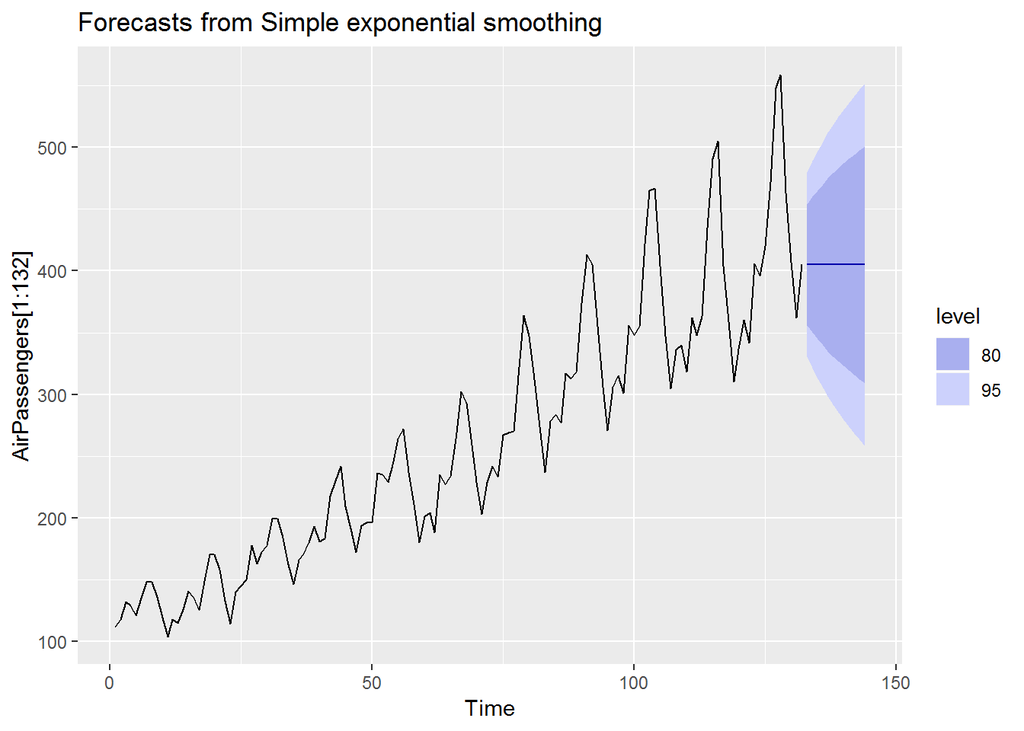

```r
autoplot(prediction)
```

# Checking the MSE with new alpha

```r
pred_val <- ses(AirPassengers[1:132],
                h = 1,
                initial = "simple",
                alpha = alpha_values$xmin)
pred_val <- as.data.frame(pred_val)
print(mse(AirPassengers[132], pred_val[,1]))
```

```
## [1] 3.756908e-13
```

##### Finding MSE

```r
original <- c(23, 17, 17, 26, 11, 23, 17)
estimated <- c(NA, NA, NA, 19, 20, 18, 20)
mse(original[!is.na(estimated)], estimated[!is.na(estimated)]) # MSE=mse(actual,predicted)
```

```
## [1] 41
```

Moving average and exponential smoothing can be used for short term predictions. In order to perform long term predictions, like forecasting values for 1 or 2 year, we need to use some other methods

## SEASONAL INDEXING

Considering the AirPassengers Data till the year 1959(yearly data: frequency = 12) assuming it to be a multiplicative model as we have seen earlier. We shall predict the future value for the year 1960 using seasonal indexing.

```r
rm(list = ls())
AirPassengers
```

```
##      Jan Feb Mar Apr May Jun Jul Aug Sep Oct Nov Dec
## 1949 112 118 132 129 121 135 148 148 136 119 104 118
## 1950 115 126 141 135 125 149 170 170 158 133 114 140
## 1951 145 150 178 163 172 178 199 199 184 162 146 166
## 1952 171 180 193 181 183 218 230 242 209 191 172 194
## 1953 196 196 236 235 229 243 264 272 237 211 180 201
## 1954 204 188 235 227 234 264 302 293 259 229 203 229
## 1955 242 233 267 269 270 315 364 347 312 274 237 278
## 1956 284 277 317 313 318 374 413 405 355 306 271 306
## 1957 315 301 356 348 355 422 465 467 404 347 305 336
## 1958 340 318 362 348 363 435 491 505 404 359 310 337
## 1959 360 342 406 396 420 472 548 559 463 407 362 405
## 1960 417 391 419 461 472 535 622 606 508 461 390 432
```

### Below are the steps to forecast the value using seasonal indexing:

```r
air_pass <- matrix(AirPassengers, ncol = 12, byrow = T)
air_pass <- air_pass[1:11,]
air_pass
```

```
##       [,1] [,2] [,3] [,4] [,5] [,6] [,7] [,8] [,9] [,10] [,11] [,12]
##  [1,]  112  118  132  129  121  135  148  148  136   119   104   118
##  [2,]  115  126  141  135  125  149  170  170  158   133   114   140
##  [3,]  145  150  178  163  172  178  199  199  184   162   146   166
##  [4,]  171  180  193  181  183  218  230  242  209   191   172   194
##  [5,]  196  196  236  235  229  243  264  272  237   211   180   201
##  [6,]  204  188  235  227  234  264  302  293  259   229   203   229
##  [7,]  242  233  267  269  270  315  364  347  312   274   237   278
##  [8,]  284  277  317  313  318  374  413  405  355   306   271   306
##  [9,]  315  301  356  348  355  422  465  467  404   347   305   336
## [10,]  340  318  362  348  363  435  491  505  404   359   310   337
## [11,]  360  342  406  396  420  472  548  559  463   407   362   405
```

#### Step 1: Calculate the average number of passengers travelling in each year.

```r
air_avg <- apply(air_pass,1,mean)
air_avg
```

```
##  [1] 126.6667 139.6667 170.1667 197.0000 225.0000 238.9167 284.0000
##  [8] 328.2500 368.4167 381.0000 428.3333
```

#### step 2 : Divide original data with corresponding year average

```r
proportion <- air_pass/air_avg
proportion
```

```
##            [,1]      [,2]      [,3]      [,4]      [,5]     [,6]     [,7]
##  [1,] 0.8842105 0.9315789 1.0421053 1.0184211 0.9552632 1.065789 1.168421
##  [2,] 0.8233890 0.9021480 1.0095465 0.9665871 0.8949881 1.066826 1.217184
##  [3,] 0.8521058 0.8814887 1.0460333 0.9578844 1.0107738 1.046033 1.169442
##  [4,] 0.8680203 0.9137056 0.9796954 0.9187817 0.9289340 1.106599 1.167513
##  [5,] 0.8711111 0.8711111 1.0488889 1.0444444 1.0177778 1.080000 1.173333
##  [6,] 0.8538542 0.7868852 0.9836066 0.9501221 0.9794210 1.104988 1.264039
##  [7,] 0.8521127 0.8204225 0.9401408 0.9471831 0.9507042 1.109155 1.281690
##  [8,] 0.8651942 0.8438690 0.9657273 0.9535415 0.9687738 1.139375 1.258187
##  [9,] 0.8550102 0.8170097 0.9662972 0.9445827 0.9635829 1.145442 1.262158
## [10,] 0.8923885 0.8346457 0.9501312 0.9133858 0.9527559 1.141732 1.288714
## [11,] 0.8404669 0.7984436 0.9478599 0.9245136 0.9805447 1.101946 1.279377
##           [,8]     [,9]     [,10]     [,11]     [,12]
##  [1,] 1.168421 1.073684 0.9394737 0.8210526 0.9315789
##  [2,] 1.217184 1.131265 0.9522673 0.8162291 1.0023866
##  [3,] 1.169442 1.081293 0.9520078 0.8579824 0.9755142
##  [4,] 1.228426 1.060914 0.9695431 0.8730964 0.9847716
##  [5,] 1.208889 1.053333 0.9377778 0.8000000 0.8933333
##  [6,] 1.226369 1.084060 0.9584932 0.8496686 0.9584932
##  [7,] 1.221831 1.098592 0.9647887 0.8345070 0.9788732
##  [8,] 1.233816 1.081493 0.9322163 0.8255903 0.9322163
##  [9,] 1.267587 1.096584 0.9418684 0.8278670 0.9120109
## [10,] 1.325459 1.060367 0.9422572 0.8136483 0.8845144
## [11,] 1.305058 1.080934 0.9501946 0.8451362 0.9455253
```

#### Step 3: Seasonal Index - Find average of each month

```r
seasonalIndex <- c()
for (temp in 1:12) {
  seasonalIndex[temp] <- mean(proportion[,temp])
}
seasonalIndex
```

```
##  [1] 0.8598058 0.8546644 0.9890939 0.9581316 0.9639563 1.1007169 1.2300053
##  [8] 1.2338620 1.0820472 0.9491716 0.8331616 0.9453835
```

#### Step 4: De-seasonalizing the real data

(if multiplicative -> divide | if additive -> subtract)

```r
deseasonalized_Air<-c()
deseasonalized_Air<-AirPassengers[1:12]/seasonalIndex
for (temp in 1:10) {                                                # Multiplication
  deseasonalized_Air<-rbind(deseasonalized_Air,AirPassengers[
    ((temp*12)+1):((temp+1)*12)]/seasonalIndex)
}
```

#### step5: Use linear regression to forecast the trend values for each month of 1960

```r
Airpass<-cbind(as.vector(t(deseasonalized_Air)),c(1:132))
reg_air<-lm(Airpass[,1]~Airpass[,2])
reg_air
```

```
##
## Call:
## lm(formula = Airpass[, 1] ~ Airpass[, 2])
##
## Coefficients:
##  (Intercept)  Airpass[, 2]
##       93.839         2.533
```

```r
#Trend values

trend_value<-c()
temp1<-1
for (temp in 133:144) {
  trend_value[temp1]<-
    reg_air$coefficients[1] + reg_air$coefficients[2]*temp
  temp1<-temp1+1
}
```

#### Step 6 : Calculate the monthly occupancy for the year 1960 by multiplying the seasonality index with the trend value

```r
pred_value<-c()
for(temp in c(1:12))
{
  pred_value[temp]<-seasonalIndex[temp]*trend_value[temp]
}
round(pred_value)
```

```
##  [1] 370 370 431 420 425 488 548 553 488 430 380 434
```

We get trend values for each month of 1960.

Sum of the seasonal index is always equal to the seasonal span. (Eg: for yearly data it is 12,quarterly data it is 4 and monthly data it is 1)

Mean of the seasonal Index is always 1.

### Stationary TS data

Use differencing to make a non-stationary TS into stationary one Diff(1) = TS[n] - TS[n-1] | Diff(2) = Diff(1)[n] - Diff(1)[n-1]

Another term - Lag (delay in TS) Lag(1) = TS[n] - TS[n-1] | Lag(2) = TS[n] - TS[n-2]

```r
rm(list = ls())
AP <- AirPassengers[1:12]
AP          # original TS
```

```
##  [1] 112 118 132 129 121 135 148 148 136 119 104 118
```

```r
diff(AP, differences = 1)              # Diff(1)
```

```
##  [1]   6  14  -3  -8  14  13   0 -12 -17 -15  14
```

```r
diff(AP, differences = 2)              # Diff(2)
```

```
##  [1]   8 -17  -5  22  -1 -13 -12  -5   2  29
```

```r
diff(AP, lag = 1)                      # Lag(1) = Diff(1) {Always}
```

```
##  [1]   6  14  -3  -8  14  13   0 -12 -17 -15  14
```

```r
diff(AP, lag = 2)                      # Lag(2)
```

```
##  [1]  20  11 -11   6  27  13 -12 -29 -32  -1
```

If we differentiate the AirPassengers Data, its Trend will be lost and mean becomes constant Also, by taking the log of original data we can also make its variance constant.

A series which is stationary after being differenced by 1 is said to be Integrated of order 1 and is denoted by I(1)

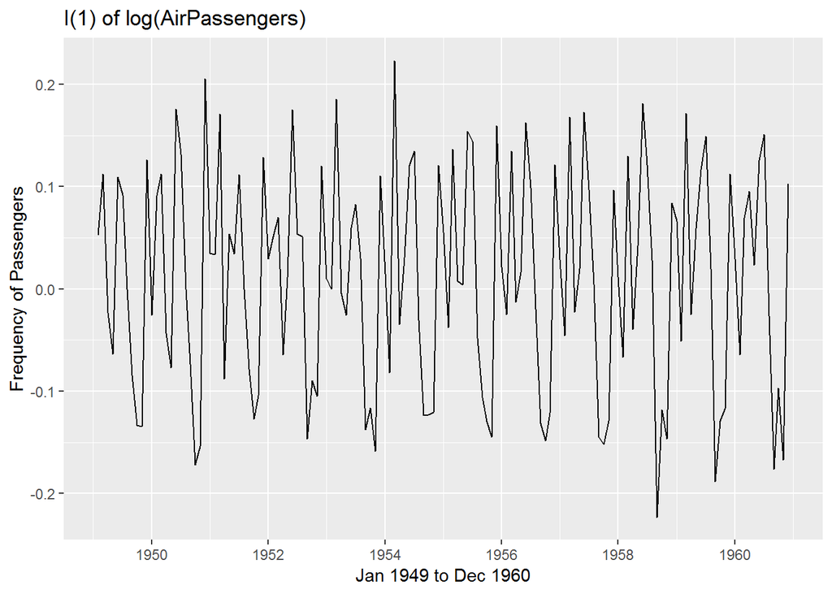

```r
autoplot(diff(log(AirPassengers)),
         ts.colour = "dodgerblue3",
         main = "I(1) of log(AirPassengers)",
         xlab = "Jan 1949 to Dec 1960",
         ylab = "Frequency of Passengers")
```

### use Dickey-Fuller test to check the stationarity of a series.

```r
library(fma)
library(forecast)
library(fma)  # for hsales data
library(TTR)  # for moving avg
library(forecast) # for exponential smoothing
library(Metrics)  # for mse - alpha calculation exponential smoothing
library(pracma)  # for alpha
library(tseries)  # dickey fueler test
```

```r
#using dickey fulter test to check stationary
library(tseries)
data("hsales")
adf.test(hsales, alternative = "stationary")
```

```
##
##  Augmented Dickey-Fuller Test
##
## data:  hsales
## Dickey-Fuller = -3.9397, Lag order = 6, p-value = 0.01247
## alternative hypothesis: stationary
```

Since the p value is 0.01247 which is less than 0.05. Hence, TS is stationary.

### Auto-Regressive Model

```r
hsales_ar <- ar(hsales[1:252],          # Last two year values excluded
                order = 1)
predict(hsales_ar,
        n.ahead = 12)                   # Yearly
```

```
## $pred
## Time Series:
## Start = 253
## End = 264
## Frequency = 1
##  [1] 51.12694 51.23690 51.33213 51.41462 51.48607 51.54795 51.60155
##  [8] 51.64798 51.68819 51.72302 51.75319 51.77932
##
## $se
## Time Series:
## Start = 253
## End = 264
## Frequency = 1
##  [1]  6.090967  8.058095  9.263571 10.073675 10.641017 11.047536 11.342953
##  [8] 11.559625 11.719547 11.838104 11.926275 11.991996
```

$pred in the below R script is the predicted value of the monthly sales of houses.

It is also possible to predict the future values by using the error terms i.e., Moving average.

## ACF and PACF

### ACF

ACF plot => 1. Decays towards zero => MA(q) component might not exist. => q=0 => 2. Abruptly goes towards zero => MA(q) component exists and value of q is determined by number of significant digits. lag after which the value of ACF is between the dashed line is chosen as the value of q.

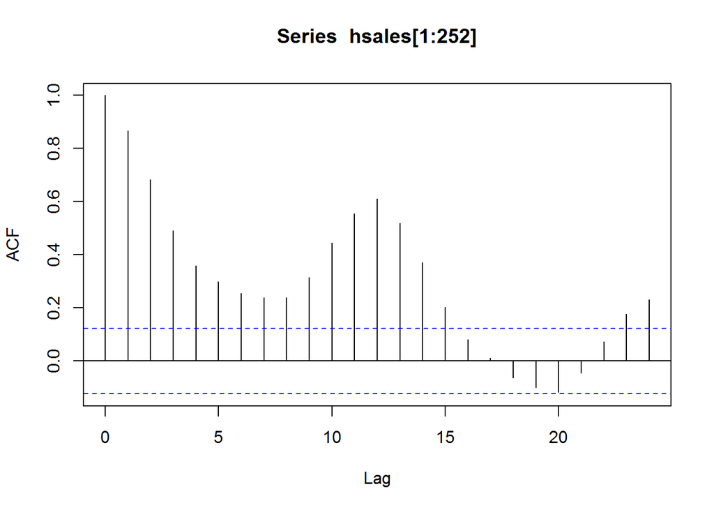

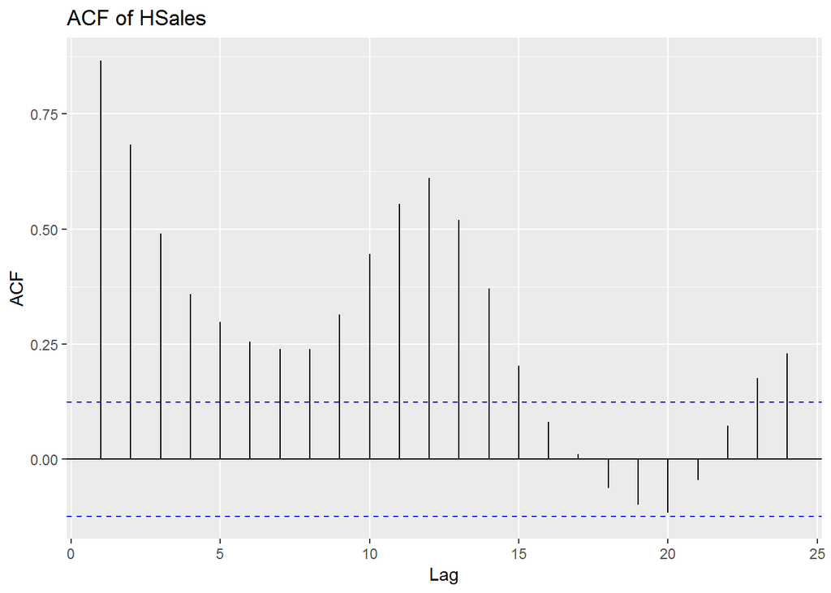

```r
autoplot(acf(hsales[1:252]),
         ts.colour = "dodgerblue3",
         main = "ACF of HSales",
         xlab = "Lag",
         ylab = "ACF")
```

**Values gradually decay towards zero. Hence, stationary Series** and TS not suitable for MA model.

=> MA(q) component might not exist

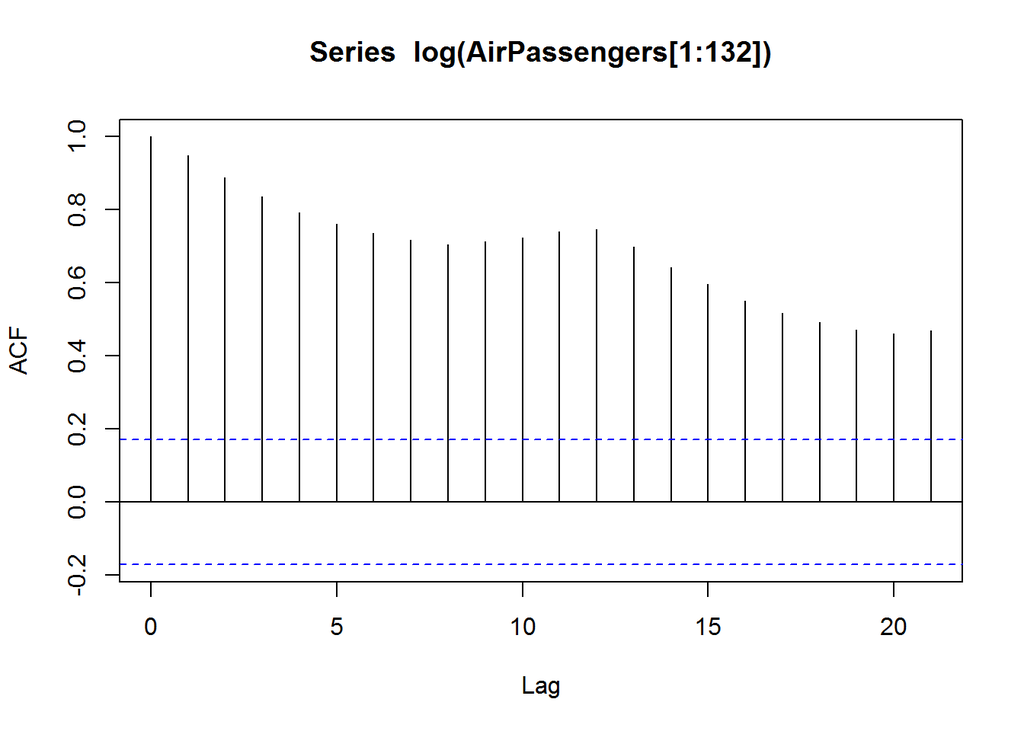

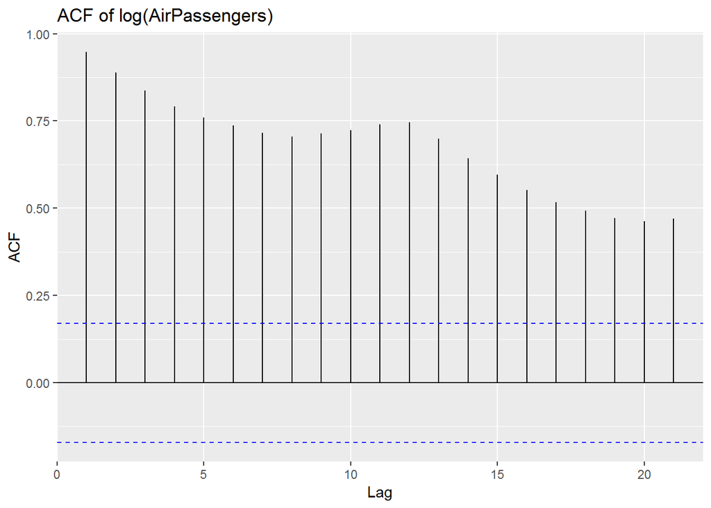

```r
autoplot(acf(log(AirPassengers[1:132])),
         ts.colour = "dodgerblue3",
         main = "ACF of log(AirPassengers)",
         xlab = "Lag",
         ylab = "ACF")
```

Values doesn’t decay towards zero. Hence, non-stationary series so taking difference.

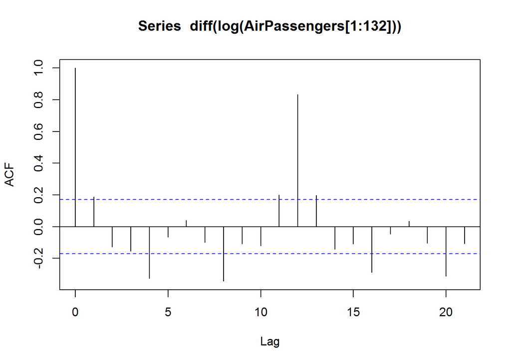

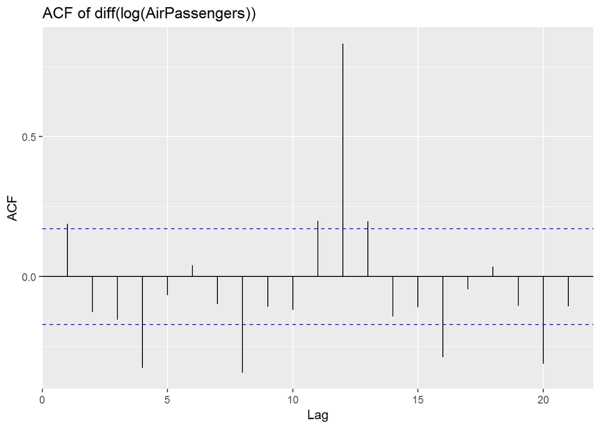

```r
autoplot(acf(diff(log(AirPassengers[1:132]))),
         ts.colour = "dodgerblue3",
         main = "ACF of diff(log(AirPassengers))",
         xlab = "Lag",
         ylab = "ACF")
```

VAlue Abruptly goes towards zero so MA(q) component exists

acf(diff(log(AirPassengers))) we can observe that q = 1.

### PACF

The abrupt movement of the spike towards 0 signifies data might have AR(p) component. The lag after which the value of PACF is between the dashed line is chosen as the value of p.

PACF plot => 1. Decays towards zero => AR(p) component might not exist. => 2. Abruptly goes towards zero => AR(p) component exists and value of p is determined by number of significant digits.

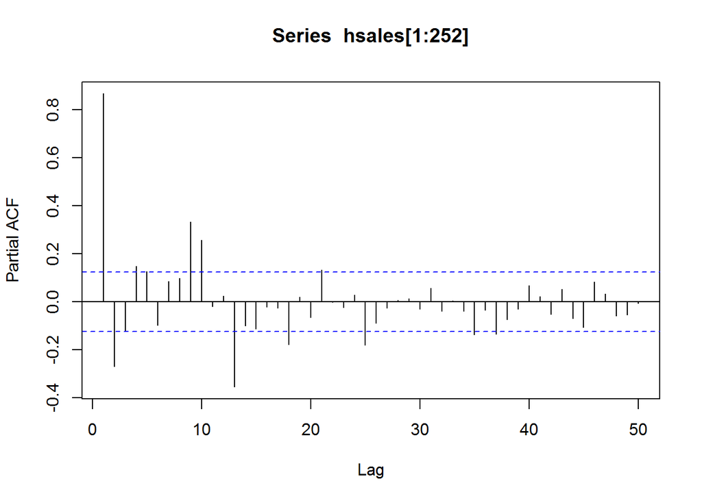

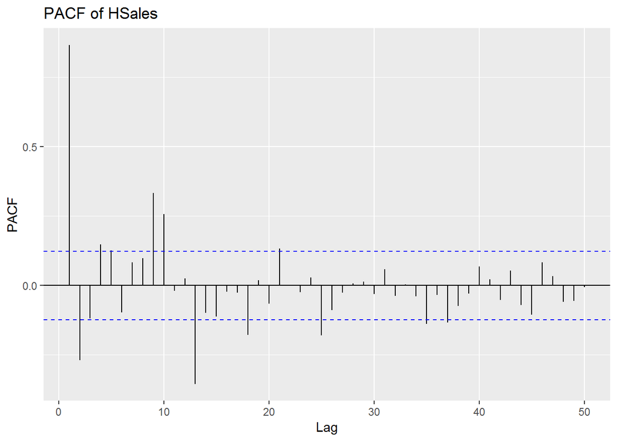

```r
autoplot(pacf(hsales[1:252],lag.max = 50),
         ts.colour = "dodgerblue3",
         main = "PACF of HSales",
         xlab = "Lag",
         ylab = "PACF")
```

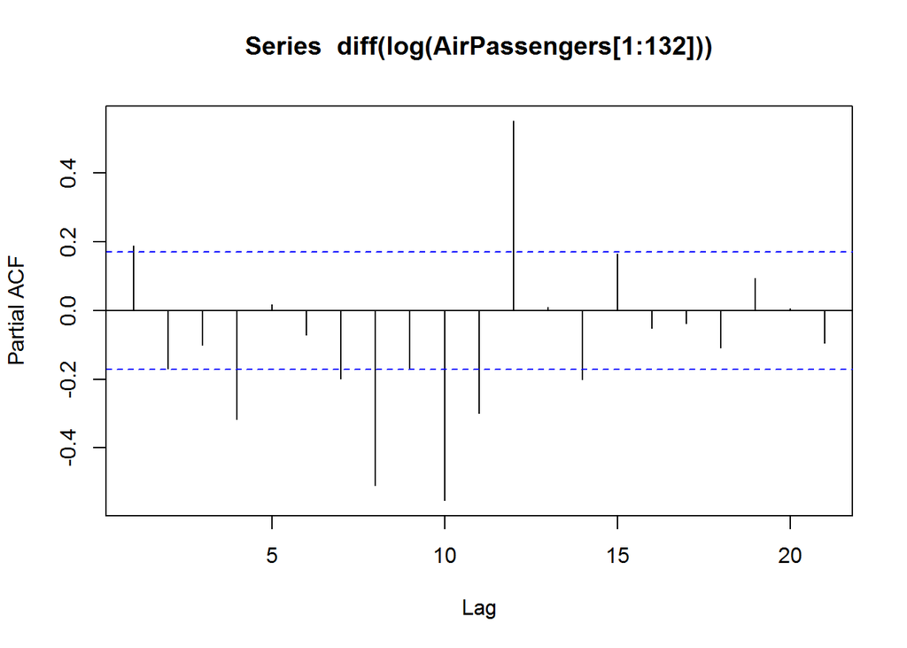

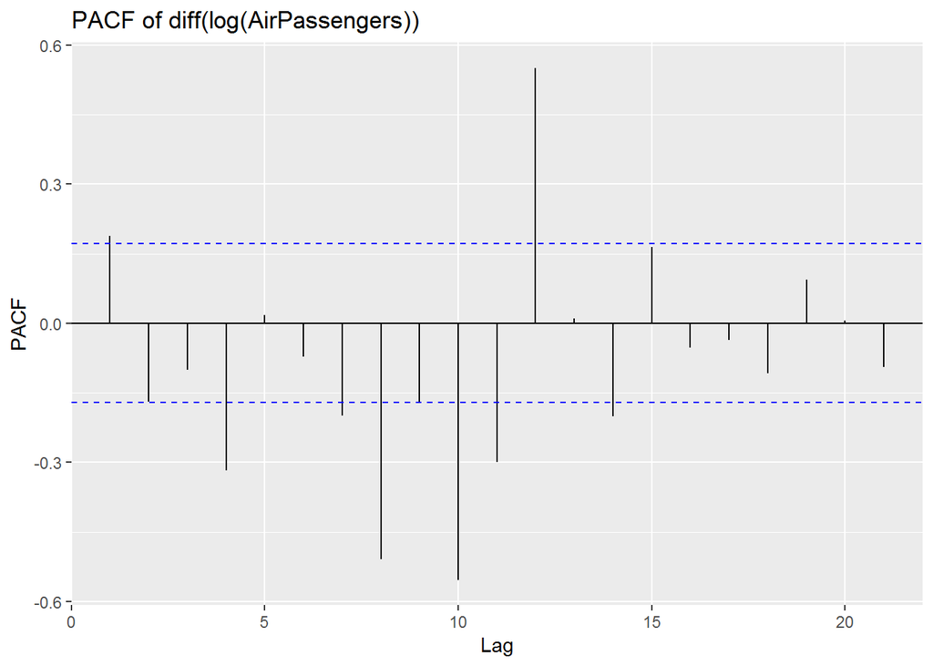

```r
autoplot(pacf(diff(log(AirPassengers[1:132]))),
         ts.colour = "dodgerblue3",
         main = "PACF of diff(log(AirPassengers))",
         xlab = "Lag",
         ylab = "PACF")
```

## Non-seasonal ARIMA(p,d,q)

Seasonal ARIMA(p,d,q)x(P,D,Q)s  
p: Autoregressive Order  
d: Integration Order  
q: Moving Average Order  
D=number of seasonal differences,  
P=number of seasonal autoregressive (SAR) terms,  
Q=number of seasonal moving average (SMA) terms  
S = seasonality period

### STEP 1 : REMOVE TREND/non-stationarity

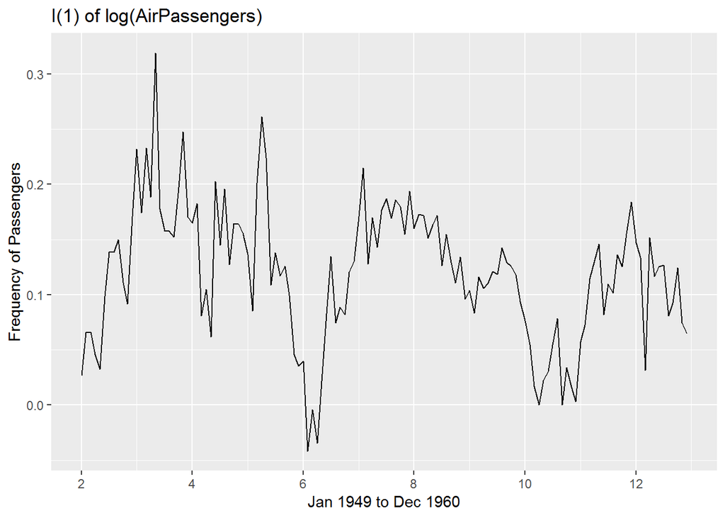

```r
seasonal_diff <- diff(ts(log(AirPassengers), frequency = 12), 12)

autoplot(seasonal_diff,
         ts.colour = "dodgerblue3",
         main = "I(1) of log(AirPassengers)",               # D=1 and d=1
         xlab = "Jan 1949 to Dec 1960",
         ylab = "Frequency of Passengers")
```

We can observe from Fig that the seasonal difference still exhibits some trend(curved). Hence we might need to difference this series again.

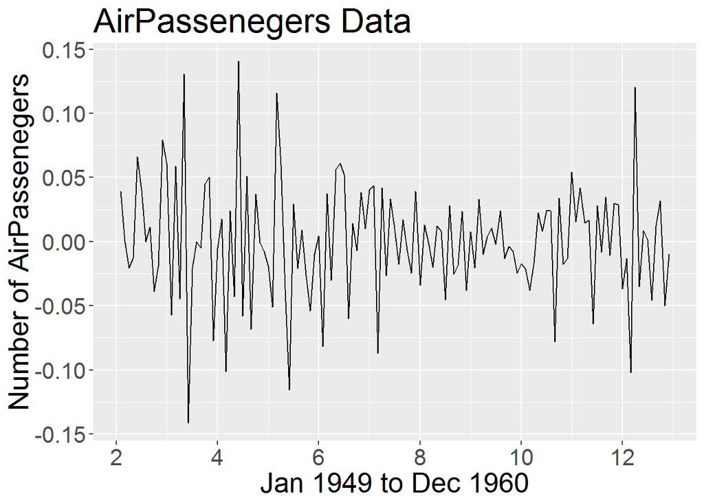

```r
seasonal_diff1 <- diff(seasonal_diff, 1)

autoplot(seasonal_diff1,
         ts.colour = ("dodgerblue3"),
         main = "AirPassenegers Data",
         xlab = "Jan 1949 to Dec 1960",
         ylab = "Number of AirPassenegers") +
  theme(text = element_text(size = 20))
```

##### If a series has a trend and no seasonality, then take the 1st difference. d = 1 and D = 1

We can observe from Fig that the series does not exhibit any proper trend. Hence we may conclude that the value of d and D should be 1.

#### OR TO CHECK FOR SEASONALITY use this test

##### if seasonal == TRUE => seasonality is present

```r
t <- tbats(seasonal_diff1)
seasonal <- !is.null(t$seasonal)
seasonal
```

```
## [1] FALSE
```

## STEP 2 : ACF plot of log(AirPassengers)(differenced by D=1 and d=1)

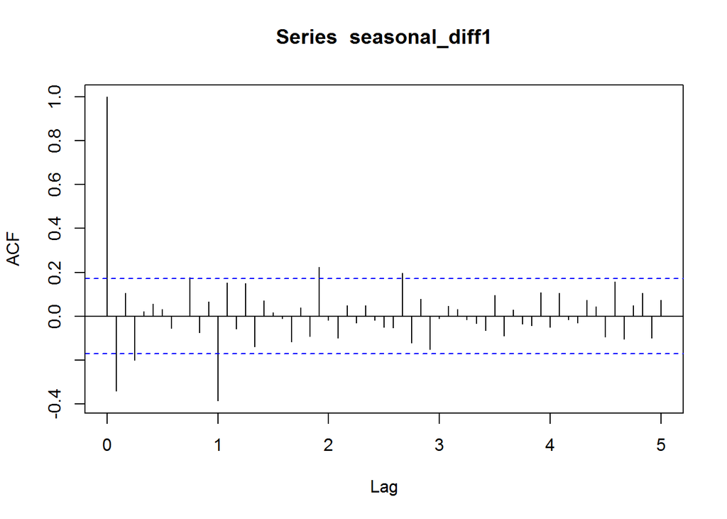

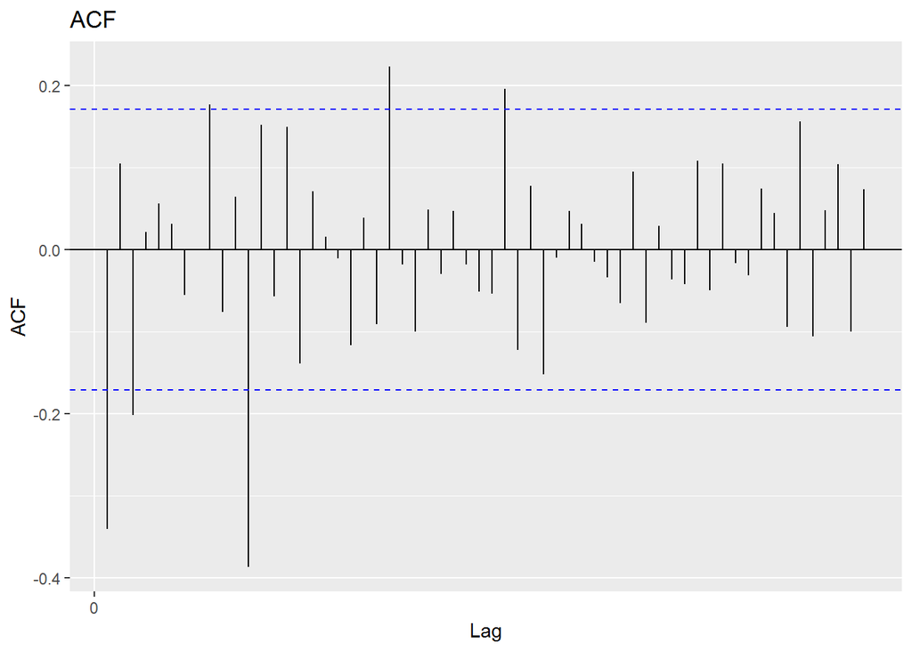

```r
autoplot(acf(seasonal_diff1, lag.max = 60),
         ts.colour = "dodgerblue3",
         main = "ACF",
         xlab = "Lag",
         ylab = "ACF")
```

Right after lag 1 values went abruptly towards zero. Hence considering MA(1) model. (MA(q) model) Since ACF => so q = 1

#### q = 1

## STEP 3 : PACF plot of log(AirPassengers)(differenced by D=1 and d=1)

After Lag 1 values abruptly goes towards zero. Hence, considering AR(1) model.

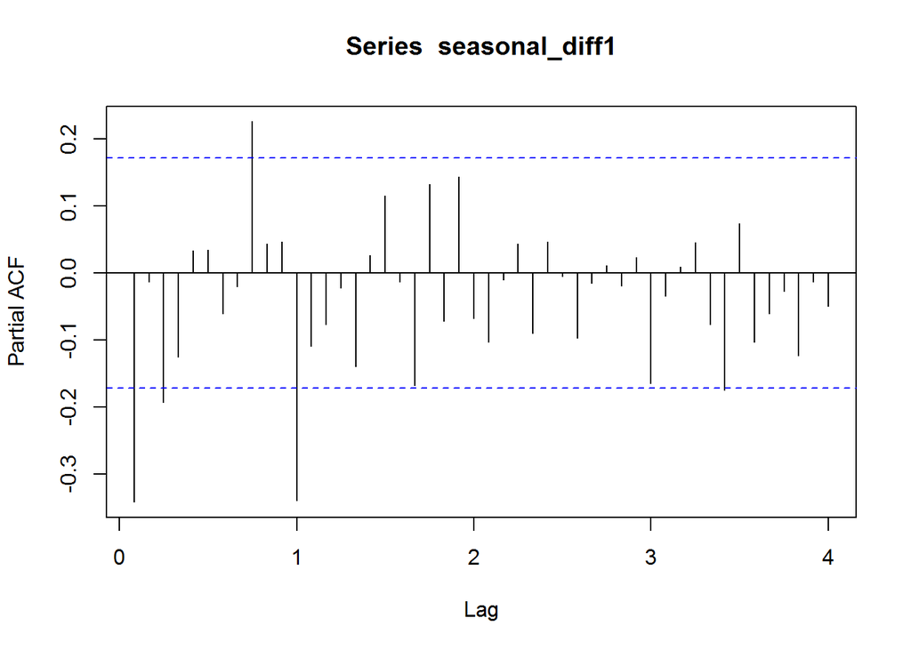

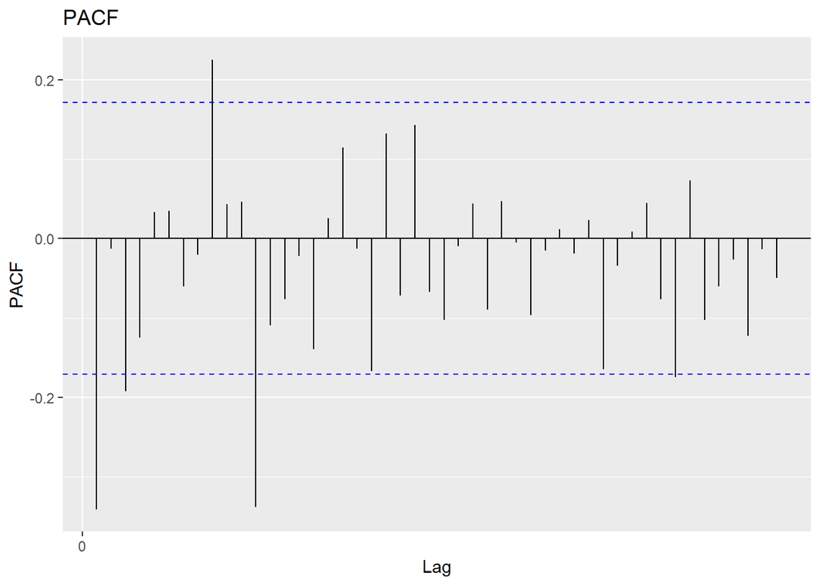

```r
autoplot(pacf(seasonal_diff1, lag.max = 48),                        #AR(p)
         ts.colour = "dodgerblue3",
         main = "PACF",
         xlab = "Lag",
         ylab = "PACF")
```

Since PACF => so p = 1

#### p = 1

## STEP 4 : FROM ACF and PCAF curve find seasonal components P and Q

ACF value is significant at lag 12, but they are also significant at lag 23 and 32.

The ACF values at higher lag (24,36,48 ) are not significant.

Maybe a SMA(1) model might work,  
as we may observe that lag 12 has a negative value in the ACF.

SO , Based on the observation below ARIMA model might give us the optimum result:

ARIMA(1,1,1)(0,1,1)12 (p,d,q) = (1,1,1) and (P,D,Q)s = (0,1,1)12

Below are the AIC values for few possible ARIMA models:

VAry values of P and Q

1. ARIMA(1,1,1)(0,1,1)12
2. ARIMA(1,1,1)(1,1,1)12
3. ARIMA(1,1,1)(0,1,0)12

Apply each of the above model to arima() to get the model and test using aic() function for lowest value

Model 1:

```r
fit <- arima(log(AirPassengers[1:132]),
             order = c(1, 1, 1),
             seasonal = list(order = c(0, 1, 1),
                             period = 12))

AIC(fit)
```

```
## [1] -439.523
```

```r
BIC(fit)
```

```
## [1] -428.4065
```

Model 2:

```r
fit <- arima(log(AirPassengers[1:132]),
             order = c(1, 1, 1),
             seasonal = list(order = c(1, 1, 1),
                             period = 12))

AIC(fit)
```

```
## [1] -437.6905
```

```r
BIC(fit)
```

```
## [1] -423.7949
```

Model 3:

```r
fit <- arima(log(AirPassengers[1:132]),
             order = c(1, 1, 1),
             seasonal = list(order = c(0, 1, 0),
                             period = 12))

AIC(fit)
```

```
## [1] -408.0094
```

```r
BIC(fit)
```

```
## [1] -399.672
```

As Model 1 has lowest value of AIC and BIC so its the best model.

ARIMA(1,1,1)(0,1,1)12

AFter choosing Predicting values for year 1960

```r
fit <- arima(log(AirPassengers[1:132]),
             order = c(1, 1, 1),
             seasonal = list(order = c(0, 1, 1),
                             period = 12))

pred_val <- exp(predict(fit, n.ahead = 12)$pred)
pred_val
```

```
## Time Series:
## Start = 133
## End = 144
## Frequency = 1
##  [1] 418.7430 397.8199 465.0983 452.9433 471.5946 545.2337 619.9384
##  [8] 627.7299 524.9364 460.6858 405.1938 450.7498
```

```r
library(Metrics)
mse(AirPassengers[133:144], pred_val)
```

```
## [1] 307.5158
```